# statistics

*01_data_basics/08_exam/01_summary_statistics_v3*

A sample’s statistic typically approaches its corresponding population parameter, but with a small sample size there is regularly error. Let’s explore this idea with an example.

A [geometric distribution](https://en.wikipedia.org/wiki/Geometric_distribution) is a well-studied discrete population. The spinner below represents a geometric distribution with the following population parameters.
$$\mu = 6.97$$
$$\sigma = 7.45$$

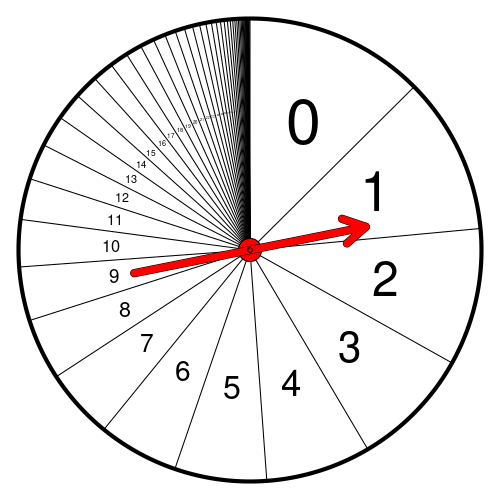

That spinner was spun many times. The raw data is displayed below and can be downloaded as a CSV.

```
7, 2, 15, 2, 2, 5, 4, 33, 2, 6, 9, 14, 8, 12, 2, 16, 17, 4, 1, 2, 3, 4, 4, 5, 3, 8, 5, 2, 1, 4, 28, 1, 14, 1, 3, 3, 5, 5, 12, 4, 1, 11, 14, 1, 1, 5, 5, 13, 9, 6, 5, 16, 1, 18, 5, 1, 5, 3, 13, 4, 15, 20, 1, 11, 2, 3, 10, 4, 22, 0, 19
```

Please calculate the following sample statistics.

1. What is the sample size? (Determine $n$.)
2. What is the sample mean? (Determine $\bar{x}$. You can round to nearest hundredth.)
3. What is the **absolute difference** between the sample mean and population mean? (Calculate $|\bar{x}-\mu|$. You can round to nearest hundredth.)
4. What is the sample median?
5. What is the sample variance? (Determine $s^2$. Use Bessel’s correction. You can round to nearest hundredth.)
6. What is the sample standard deviation? (Determine $s$. Use Bessel’s correction. You can round to nearest hundredth.)
7. What is the **absolute difference** between the sample standard deviation and population standard deviation? (Calculate $|s-\sigma|$. You can round to nearest hundredth.)